# Part II - Effects of Gender and User Type on Duration of a Trip

## by Abdellah Ait Ahmed Ouaal

## Investigation Overview

In this investigation, I want to present the effect of the two predictor factors gender and user type on the duration of the trip.

## Dataset Overview

The dataset consists of 183413 records concerning individual trips. The attributes included the two categorical variables gender(male, female, other) and user type(subscriber or customer), as well as starting and ending times

## Distribution of Duration of The Trip

The duration of each trip in seconds take a very large range of values, with the lowest value 61s to the highest value 84548s. Plotted on a logarithmic scale, this distribution take a log-normal shape which means the vast majority of durations are between 200s and 1000s, and very little of them are either under 200s or more than 1000s.

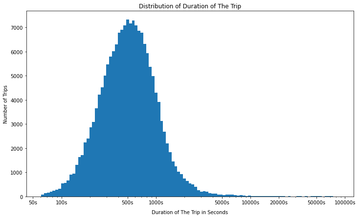

## The Proportion of Each User Type and Gender

Among all users we show the proportion of each user type: customer or subscriber, and gender: male, female or other. We find that about 90% of users are subscribers, also near to 75% of users are men.

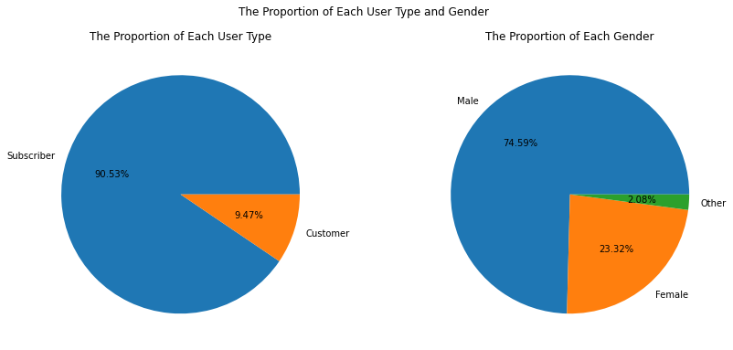

## The Effect of User Type on The Duration

We plot the relation between user type and duration in a log scale, then we can see that customers take trips of long duration comparing to subscribers, which is totally normal due to the fact that customers are usually first time customers, then they will take a longer trip duration.

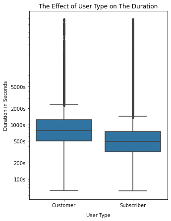

## The Effect of Gender on The Duration

We plot the relation between ugender and duration in a log scale, we could say that men have shorter trips comparing to other genders which was an unexpected outcome for me.

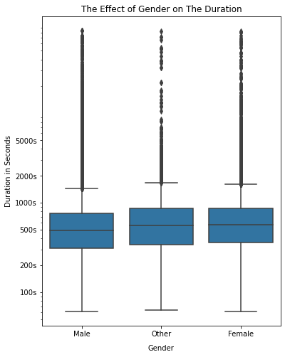

## Duration by Gender and User Type

We plot our last case with two qualitative variables (gender and user type) and one quantitative variable: the duration. We conclude that customers' trips are longer in duration than subscribers' trips across all genders, which is a generalisation of the previous result in all genders.

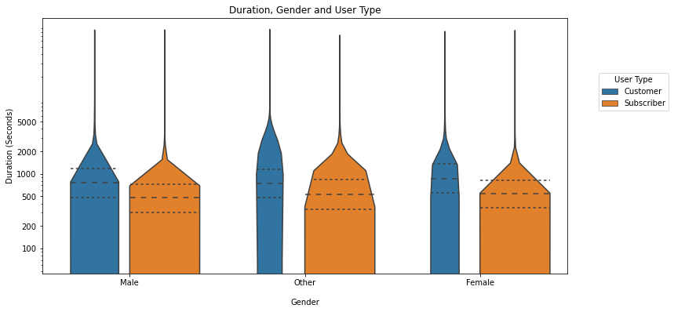